# Test basic functionalities of scGate on human data: Myeloid antigen presenting cells

## Gating TCD8 cells: two layered model.

A scGate multi-layer model is simply an R list of scGate models (warning: order matters). Models will be executed in an itterative manner

```r
## explore the pre-built two-layer model.
TCD8.model <- scGate_DB$human$CD8.Tcell
TCD8.model %>%
    class()
```

```
[1] "list"
```

```r
TCD8.model %>%
    names()
```

```
[1] "T.cell"    "Tcell_CD8"
```

```r
class(TCD8.model[["Tcell_CD8"]])
```

```
[1] "scGate_Model"
attr(,"package")
[1] "scGate"
```

We only need to apply the two layer pre-trained model of TCD8 cells available in scGate_DB * This may take a few minutes, you can drink a cup of coffee in the meantime.

```r
if(!file.exists('./input/tcd8.human.sets.rds')){
  tcd8.gating <- lapply(dataset.list,function(data){
    gated.object <- scGate(data = data, gating.model = scGate_DB$human$CD8.Tcell,
                           sd.in = 4,
                           sd.out = 7,  # reducing this threshold the gating will be more conservative
                           return_signature_scores = T)
    return(gated.object)
  })
  saveRDS(tcd8.gating,'./input/tcd8.human.sets.rds')

}else{
  tcd8.gating <- readRDS('./input/tcd8.human.sets.rds')
}
```

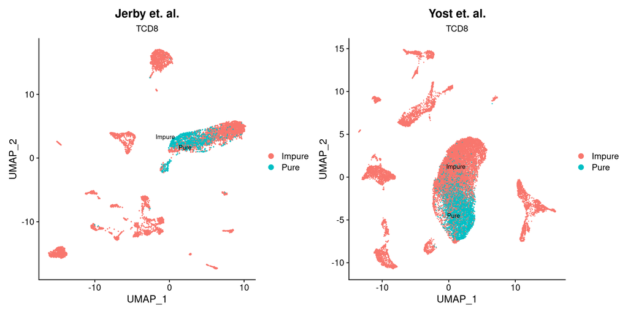

```r
jerby.plot <- DimPlot(object = tcd8.gating$Jerby, reduction = "umap", group.by = "is.pure",
    label = TRUE, label.size = 3, repel = TRUE) + ggtitle("Jerby et. al.") + labs(subtitle = "TCD8") +
    theme(plot.subtitle = element_text(hjust = 0.5))


yost.plot <- DimPlot(object = tcd8.gating$Yost, reduction = "umap", group.by = "is.pure",
    label = TRUE, label.size = 3, repel = TRUE) + ggtitle("Yost et. al.") + labs(subtitle = "TCD8") +
    theme(plot.subtitle = element_text(hjust = 0.5))

jerby.plot + yost.plot
```

Comparing results among authors’ defined cell types

```r
writeLines("td, th { padding : 6px } th { background-color : brown ; color : white; border : 1px solid white; } td { color : brown ; border : 1px solid brown }",
    con = "mystyle.css")

# Jerby
knitr::kable(table(tcd8.gating$Jerby@meta.data[, c("cell_type", "is.pure")]), format = "html")
```

|  | Impure | Pure |
| --- | --- | --- |
| ? | 0 | 0 |
| B.cell | 814 | 4 |
| CAF | 104 | 2 |
| Endo. | 104 | 0 |
| Macrophage | 419 | 1 |
| Mal | 2014 | 4 |
| NK | 86 | 6 |
| T.CD4 | 779 | 77 |
| T.CD8 | 685 | 1074 |
| T.cell | 610 | 96 |

```r
# Yost
knitr::kable(table(tcd8.gating$Yost@meta.data[, c("cell_type", "is.pure")]), format = "html")
```

|  | Impure | Pure |
| --- | --- | --- |
| B_cells_1 | 108 | 0 |
| B_cells_2 | 5 | 0 |
| CAFs | 638 | 0 |
| CD4_T_cells | 3956 | 44 |
| CD8_act_T_cells | 225 | 72 |
| CD8_ex_T_cells | 847 | 344 |
| CD8_mem_T_cells | 2515 | 3725 |
| DCs | 170 | 0 |
| Endothelial | 242 | 0 |
| Macrophages | 1160 | 0 |
| Melanocytes | 89 | 0 |
| Myofibroblasts | 164 | 0 |
| NK_cells | 208 | 4 |
| pDCs | 230 | 1 |
| Plasma_cells | 1714 | 0 |
| Tcell_prolif | 195 | 0 |
| Tregs | 2102 | 8 |
| Tumor_1 | 1535 | 0 |
| Tumor_2 | 1027 | 0 |

## Further reading

The code and the package are available at the *scGate* [GitHub repository](https://github.com/carmonalab/scGate)

```r
# renv::snapshot()
```